# evaluation

```python
import numpy as np
import matplotlib.pyplot as plt
import pandas as pd
from sklearn.datasets import load_iris, load_wine, load_breast_cancer, make_blobs
from sklearn.decomposition import PCA
from sklearn.manifold import TSNE
import umap
from sklearn.preprocessing import StandardScaler
from sklearn.neighbors import NearestNeighbors
from sklearn.metrics import silhouette_score
import seaborn as sns
import warnings
from sklearn.datasets import fetch_openml
from sklearn.model_selection import GridSearchCV, RandomizedSearchCV, cross_val_score
from sklearn.linear_model import LogisticRegression
from sklearn.ensemble import RandomForestClassifier
from sklearn.svm import SVC
from sklearn.metrics import accuracy_score
from itertools import product
import optuna
import os
from typing import Dict, List, Tuple, Any
warnings.filterwarnings('ignore')
from IPython.display import display, HTML
from sklearn.model_selection import GridSearchCV
from sklearn.decomposition import PCA
from sklearn.svm import SVC
from sklearn.model_selection import StratifiedKFold, ParameterGrid
from sklearn.model_selection import train_test_split
from sklearn.linear_model import LogisticRegression
from sklearn.ensemble import RandomForestClassifier
from sklearn.svm import SVC
from sklearn.metrics import accuracy_score, f1_score, precision_score, recall_score
from sklearn.preprocessing import LabelEncoder
from sklearn.metrics import pairwise_distances
from sklearn.neighbors import KNeighborsClassifier
from sklearn.cluster import KMeans
from sklearn.preprocessing import MinMaxScaler
from scipy.stats import kendalltau, spearmanr
display(HTML("<style>.output_scroll {height: 300px; overflow-y: scroll;}</style>"))
plt.rcParams.update({
    'text.usetex': False,
    'font.family': 'sans-serif',
    'font.size': 12
})
```

```python
# SVD-based RankMe (added to replace previous row-norm proxy)
import numpy as np

def rankme(embeddings, epsilon=1e-12):
    """
    Compute the RankMe score using the singular values of the embedding matrix.

    Implementation note:
    - Uses SVD on the embedding matrix to obtain singular values.
    - Normalizes singular values to a probability distribution, computes
      Shannon entropy and returns exp(entropy) as RankMe.
    - Falls back to SVD on covariance if direct SVD fails.
    """
    embeddings = np.asarray(embeddings, dtype=float)
    if embeddings.size == 0:
        return 0.0
    if embeddings.shape[0] <= 1 or embeddings.shape[1] == 0:
        return 0.0
    try:
        s = np.linalg.svd(embeddings, compute_uv=False)
    except np.linalg.LinAlgError:
        cov = np.cov(embeddings.T)
        s = np.linalg.svd(cov, compute_uv=False)
    s = np.abs(s)
    s = s[s > epsilon]
    if s.size == 0:
        return 0.0
    pk = s / (np.sum(s) + epsilon)
    entropy = -np.sum(pk * np.log(pk + epsilon))
    return float(np.exp(entropy))
```

## 1. Research Objectives and Background

Project Supervisor: Louis Ohl louis.ohl@liu.se

Recommended pre-requisite courses: 732A83, 732A870, 732A99, 732A82

The growth of representation learning methods, e.g. SIMCLR, DINO, is a milestone of the recent deep learning achievements in self-supervised learning, providing generic features that can be repurposed for downstream tasks. However, one of the main mean of evaluation for these models remain the ability to perform downstream tasks, notably with post-hoc classification. Few works have proposed instead scoring methods to evaluate the features per se: RankMe, CLID, or alignment to name a few.

The goal of this research project is to assess those different internal metrics on dimension reduction contexts. Dimension reduction is the first basic tool used for visualisation, but it can also be used to simply to provide an alternative representation of the dataset at any lower dimension.

The selected student is expected to implement CLID, Rankme, or any other score of choice and evaluate their applicability on different dimension reduction techniques: PCA, TSNE and UMAP. Datasets will be free to choose among UCI tabular datasets.

1. Wang, T., & Isola, P. (2020, November). Understanding contrastive representation learning through alignment and uniformity on the hypersphere. In International conference on machine learning (pp. 9929-9939). PMLR.
2. Garrido, Q., Balestriero, R., Najman, L., & Lecun, Y. (2023, July). Rankme: Assessing the downstream performance of pretrained self-supervised representations by their rank. In International conference on machine learning (pp. 10929-10974). PMLR.
3. Lu, Y., Liu, Z., Baratin, A., Laroche, R., Courville, A., & Sordoni, A. Using Representation Expressiveness and Learnability to Evaluate Self-Supervised Learning Methods. Transactions on Machine Learning Research.

## 2. Datasets

We try to evaluate the intric metric using the data of different dimensions, below dataset from UCI is selected applying to our experiment.

```python
def load_datasets():
    """
    Load multiple UCI datasets for dimensionality reduction evaluation.

    Returns:
    --------
    datasets : dict
        Dictionary containing dataset name as key and data/target as value
    """
    datasets = {}

    # 1. Iris dataset (4D, 150 samples, 3 classes)
    iris = load_iris()
    datasets['Iris'] = {
        'data': iris.data,
        'target': iris.target,
        'feature_names': iris.feature_names,
        'target_names': iris.target_names
    }

    # 2. Wine dataset (13D, 178 samples, 3 classes)
    wine = load_wine()
    datasets['Wine'] = {
        'data': wine.data,
        'target': wine.target,
        'feature_names': wine.feature_names,
        'target_names': wine.target_names
    }

    # 3. Breast Cancer dataset (30D, 569 samples, 2 classes)
    cancer = load_breast_cancer()
    datasets['Breast Cancer'] = {
        'data': cancer.data,
        'target': cancer.target,
        'feature_names': cancer.feature_names,
        'target_names': cancer.target_names
    }

    # 4. Digits dataset (64D, 1797 samples, 10 classes)
    from sklearn.datasets import load_digits
    digits = load_digits()
    datasets['Digits'] = {
        'data': digits.data,
        'target': digits.target,
        'feature_names': [f'pixel_{i}' for i in range(64)],
        'target_names': digits.target_names
    }

    # 5. Olivetti Faces dataset (4096D -> 400D via PCA, 400 samples, 40 classes)
    try:
        from sklearn.datasets import fetch_olivetti_faces
        faces = fetch_olivetti_faces(shuffle=True, random_state=42)
        # Reduce to 400D using PCA to make it manageable
        # from sklearn.decomposition import PCA
        # pca = PCA(n_components=400, random_state=42)
        # faces_reduced = pca.fit_transform(faces.data)
        datasets['Olivetti Faces'] = {
            'data': faces.data,
            'target': faces.target,
            'target_names': [f'person_{i}' for i in range(40)]
        }
    except Exception as e:
        print(f"Failed to load Olivetti Faces: {e}")

    # 6. Synthetic Clusters (20D, 1000 samples, 5 clusters)
    from sklearn.datasets import make_blobs
    X_synthetic, y_synthetic = make_blobs(
        n_samples=1000,
        n_features=20,
        centers=5,
        cluster_std=1.0,
        random_state=42
    )
    datasets['Synthetic Clusters'] = {
        'data': X_synthetic,
        'target': y_synthetic,
        'feature_names': [f'feature_{i}' for i in range(20)],
        'target_names': [f'cluster_{i}' for i in range(5)]
    }

    # 7. German Credit dataset (20D, 1000 samples, 2 classes)
    try:
        # Try to load from OpenML
        from sklearn.datasets import fetch_openml
        credit = fetch_openml('credit-g', version=1, as_frame=False, parser='auto')
        # Convert categorical features to numerical
        from sklearn.preprocessing import LabelEncoder
        X_credit = credit.data
        y_credit = credit.target

        # Encode target
        le = LabelEncoder()
        y_credit_encoded = le.fit_transform(y_credit)

        datasets['German Credit'] = {
            'data': X_credit,
            'target': y_credit_encoded,
            'feature_names': credit.feature_names if hasattr(credit, 'feature_names') else [f'feature_{i}' for i in range(X_credit.shape[1])],
            'target_names': ['good', 'bad']
        }
    except Exception as e:
        print(f"Failed to load German Credit dataset: {e}")
        print("Continuing without German Credit dataset...")

    return datasets


def preprocess_data(data):
    """
    Standardize the input data using StandardScaler.

    Parameters:
    -----------
    data : numpy.ndarray
        Input data matrix

    Returns:
    --------
    data_standardized : numpy.ndarray
        Standardized data with zero mean and unit variance
    """
    scaler = StandardScaler()
    data_standardized = scaler.fit_transform(data)
    return data_standardized
```

## 3. Methods

- **Dimensionality reduction**: PCA, t-SNE, UMAP, with parameter grids automatically adapted to data shape.
- **Internal metrics**: RankMe, CLID.
- **Classification evaluation**: Logistic Regression on reduced features, recording accuracy.
- **Parameter optimization**: Fixed parameters to avoid confounding factors, multiple random seeds for robustness.
- **Correlation analysis**: Analyzes the relationship between internal metrics and classification accuracy.

```python
import numpy as np
from sklearn.metrics import pairwise_distances

def rankme(embeddings, epsilon=1e-12):
    """
    Compute the RankMe score using the singular values of the embedding matrix.

    This follows the idea in Garrido et al. (2023): use the singular values
    of the representation matrix (or covariance if SVD on the matrix fails),
    normalize them to form a probability distribution, compute Shannon entropy
    and return exp(entropy) as the RankMe value.

    Parameters
    ----------
    embeddings : array-like, shape (n_samples, n_features)
        Embedding matrix where each row is a sample vector.
    epsilon : float
        Numerical stability constant to avoid log(0).

    Returns
    -------
    rankme_value : float
        RankMe score (>= 0). Higher means effectively higher rank/expressiveness.
    """
    embeddings = np.asarray(embeddings, dtype=float)
    # handle trivial cases
    if embeddings.size == 0:
        raise Exception("No data")
    # If there is only one sample or one feature, return a default
    if embeddings.shape[0] <= 1 or embeddings.shape[1] == 0:
        raise Exception("Insufficient data")


    # Compute singular values of the embedding matrix
    s = np.linalg.svd(embeddings, compute_uv=False)


    s = np.abs(s)
    s = s[s > epsilon]
    if s.size == 0:
        return 0.0

    pk = s / (np.sum(s) + epsilon)
    entropy = -np.sum(pk * np.log(pk + epsilon))
    rankme_value = float(np.exp(entropy))
    return rankme_value
```

```python
def estimate_intrinsic_dimension(Z, metric="euclidean"):
    D = pairwise_distances(Z, metric=metric)
    np.fill_diagonal(D, np.inf) # set the self-distance to inf
    r_sorted = np.sort(D, axis=1)
    r1, r2 = r_sorted[:, 0], r_sorted[:, 1]
    mu = r2/r1
    mu = mu[np.isfinite(mu) & (mu > 1.0)]
    mu_sorted = np.sort(mu)
    N = len(mu_sorted)
    F_emp = np.arange(1, N + 1) / N

    x = np.log(mu_sorted)
    y = -np.log(1 - F_emp + 1e-10)
    slope, _ = np.polyfit(x, y, 1)
    return slope
```

```python
def cluster_learnability(Z, n_clusters=3, k=5, metric="euclidean", random_state=42):
    """
    Estimate cluster learnability using KMeans + KNN classification accuracy.

    Methodology (Lu et al., 2023):
    1. Use KMeans to create pseudo-labels (unsupervised clustering)
    2. Train KNN classifier on these pseudo-labels
    3. Measure how well the structure can be learned

    Higher accuracy → clearer cluster structure → better learnability

    Parameters:
    -----------
    Z : numpy.ndarray
        Input embeddings (n_samples, n_features)
    n_clusters : int
        Target number of clusters (default=3)
    k : int
        Number of neighbors for KNN (default=5)
    metric : str
        Distance metric for KNN (default='euclidean')
    random_state : int
        Random seed for reproducibility

    Returns:
    --------
    acc : float
        Cluster learnability score (KNN accuracy on pseudo-labels), range [0, 1]
    """
    N = len(Z)

    # Ensure we have enough samples
    if N < 10:
        raise ValueError("Not enough samples to compute cluster learnability.")

    n_clusters = max(2, min(n_clusters, N // 10))

    # Generate pseudo-labels using KMeans
    kmeans = KMeans(n_clusters=n_clusters, random_state=random_state, n_init=10)
    pseudo_labels = kmeans.fit_predict(Z)

    rng = np.random.RandomState(random_state)
    idx = np.arange(N)
    rng.shuffle(idx)
    split = int(0.8 * N)
    train_idx, val_idx = idx[:split], idx[split:]

    # Ensure we have validation samples
    if len(val_idx) == 0:
        raise ValueError("Not enough samples for validation split.")

    # Determine k for KNN (must be less than training set size)
    k = min(k, len(train_idx) - 1)
    if k < 1:
        k = 1

    # Train KNN on pseudo-labels and evaluate
    try:
        knn = KNeighborsClassifier(n_neighbors=k, metric=metric)
        knn.fit(Z[train_idx], pseudo_labels[train_idx])
        pred = knn.predict(Z[val_idx])
        acc = accuracy_score(pseudo_labels[val_idx], pred)
        return acc
    except Exception as e:

        raise ValueError("Failed to compute cluster learnability due to an error.")

def clid_score_cross_models(embeddings_dict:Dict[str, List[np.ndarray]], n_clusters=3):
    """
    Compute CLID scores across multiple embedding models.
    according to Lu et al., 2023.  normmaized the sum of Cluster Learnability and Intrinsic Dimension on different models
    to get different models' CLID scores. we use different random states to compute cluster learnability to get more robust results.
    """
    CL_vals = []
    ID_vals = []
    CLID_dict = {}
    for emb_name, emb in embeddings_dict.items():
        CLID_dict[emb_name] = None
        # Compute Cluster Learnability: range [0, 1]
        cl = cluster_learnability(emb, n_clusters=n_clusters)

        # Compute Intrinsic Dimension estimate
        id_est = estimate_intrinsic_dimension(emb)
        CL_vals.append(cl)
        ID_vals.append(id_est)
        # Normalize ID by embedding dimension to [0, 1]
        # embedding_dim = emb.shape[1]
        # id_normalized = np.clip(id_est / embedding_dim, 0, 1)
    CL_vals = np.array(CL_vals, dtype=float)
    ID_vals = np.array(ID_vals, dtype=float)
    def minmax_norm(arr):
        mn = np.nanmin(arr)
        mx = np.nanmax(arr)
        if np.isclose(mx, mn):

            return np.ones_like(arr) * 0.5
        return (arr - mn) / (mx - mn)

    CL_norm = minmax_norm(CL_vals)
    ID_norm = minmax_norm(ID_vals)
    CLID = CL_norm + ID_norm
    for key, clid_val in zip(CLID_dict.keys(), CLID):
        CLID_dict[key] = clid_val

    return CLID_dict


def uniformity(embeddings, t=2):
    """
    Compute uniformity metric for embeddings (Wang et al., 2020).

    Measures how uniformly embeddings are distributed on the hypersphere.
    Lower (more negative) values indicate more uniform distribution.

    Parameters:
    -----------
    embeddings : numpy.ndarray
        Embedding matrix (n_samples, n_features)
    t : float
        Temperature parameter (default=2)

    Returns:
    --------
    uniformity_score : float
        Uniformity score (typically negative)
    """
    normalized = embeddings / (np.linalg.norm(embeddings, axis=1, keepdims=True) + 1e-8)
    pairwise_sq_dists = np.sum((normalized[:, None, :] - normalized[None, :, :]) ** 2, axis=2)
    return np.log(np.mean(np.exp(-t * pairwise_sq_dists)))
```

```python
from sklearn.model_selection import StratifiedKFold
from tqdm import tqdm
def classification_evaluation(embeddings, labels, cv=5, random_state=42):
    """
    Evaluate classification performance using StratifiedKFold cross-validation.
    only use Logistic Regression to prevent from intrdoducing too much variance.
    """
    from sklearn.linear_model import LogisticRegression
    from sklearn.ensemble import RandomForestClassifier
    from sklearn.svm import SVC
    from sklearn.metrics import accuracy_score, f1_score, precision_score, recall_score
    from sklearn.preprocessing import LabelEncoder

    le = LabelEncoder()
    labels_encoded = le.fit_transform(labels)
    # fixed: only use Logistic Regression
    classifiers = {
        'Logistic Regression': LogisticRegression(
            random_state=random_state,
            solver='lbfgs',
            max_iter=1000)
    }
    # classifiers = {
    #     'Logistic Regression': LogisticRegression(random_state=random_state, max_iter=1000),
    #     'Random Forest': RandomForestClassifier(random_state=random_state, n_estimators=100),
    #     'SVM': SVC(random_state=random_state, kernel='rbf')
    # }
    results = {}
    best_score = -float('inf')
    skf = StratifiedKFold(n_splits=cv, shuffle=True, random_state=random_state)
    for clf_name, clf in classifiers.items():
        cv_scores = []
        f1_scores = []
        precision_scores = []
        recall_scores = []
        for train_idx, test_idx in skf.split(embeddings, labels_encoded):
            X_train, X_test = embeddings[train_idx], embeddings[test_idx]
            y_train, y_test = labels_encoded[train_idx], labels_encoded[test_idx]
            clf.fit(X_train, y_train)
            y_pred = clf.predict(X_test)
            cv_scores.append(accuracy_score(y_test, y_pred))
            f1_scores.append(f1_score(y_test, y_pred, average='weighted'))
            precision_scores.append(precision_score(y_test, y_pred, average='weighted', zero_division=0))
            recall_scores.append(recall_score(y_test, y_pred, average='weighted'))
        mean_score = np.mean(cv_scores)
        if mean_score > best_score:
            best_score = mean_score
            best_classifier = clf_name
            results['best_accuracy'] = mean_score
            results['best_classifier'] = clf_name
        results[f'{clf_name}_accuracy'] = mean_score
        results[f'{clf_name}_f1'] = np.mean(f1_scores)
        results[f'{clf_name}_precision'] = np.mean(precision_scores)
        results[f'{clf_name}_recall'] = np.mean(recall_scores)
    return results


def comprehensive_evaluation_with_classification(embeddings, labels, name="Unknown", print_results=False):

    results = {}

    try:
        # 1. RankMe: Representation quality metric (Garrido et al., 2023)
        results['rankme'] = rankme(embeddings)

        # 2. Uniformity: Distribution uniformity on hypersphere (Wang et al., 2020)
        # try:
        #     results['uniformity'] = uniformity(embeddings, t=2)
        # except Exception as e:
        #     if print_results:
        #         print(f"Warning: Failed to compute uniformity for {name}: {e}")
        #     results['uniformity'] = np.nan

        # 3. Classification performance
        if labels is not None and len(np.unique(labels)) > 1:
            classification_results = classification_evaluation(embeddings, labels)
            results.update(classification_results)

    except Exception as e:
        print(f"Error during evaluation of {name}: {e}")

    return results
```

```python
from sklearn.utils import resample

def apply_dimension_reduction(data, method='pca', **params):
    """
    apply different dimension reduction techniques
    Parameters:
    -----------
    data : numpy.ndarray
    method : str
        reduction method   ：'pca', 'tsne', 'umap'
    n_components : int
    **kwargs : dict
    Returns:
    --------
    reduced_data : numpy.ndarray
    """
    # the result of dimension reduction is nothing to do with the random state
    if method.lower() == 'pca':
        rng = np.random.RandomState(params.get('random_state', None))
        Xb = resample(data, replace=True, n_samples=data.shape[0], random_state=rng)
        pca = PCA(n_components=params.get('n_components', None))
        pca.fit(Xb)
        return pca.transform(data)


    elif method.lower() == 'tsne':

        tsne_params = params.copy()
        if 'tsne_method' in tsne_params:
            tsne_params['method'] = tsne_params.pop('tsne_method')

        reducer = TSNE(**tsne_params)
        return reducer.fit_transform(data)

    elif method.lower() == 'umap':
        reducer = umap.UMAP(**params)
        return reducer.fit_transform(data)

    else:
        raise ValueError(f"Applying a unknown method: {method}")
```

```python
def get_fixed_parameters(method,random_state_list = [42, 52, 62, 72, 82], n_components=2, n_samples=None):
    '''
    Get fixed parameters for different dimension reduction methods.
    '''
    params_list = []
    for random_state in random_state_list:


        if method.lower() == 'pca':
            params_list.append({
                'n_components': n_components,
                'whiten': False,
                'svd_solver': 'auto',
                'random_state': random_state
            })

        elif method.lower() == 'tsne':

            if n_components > 3:
                # Barnes-Hut doesn't support >3D, must use exact
                tsne_method = 'exact'
            elif n_samples is not None and n_samples < 500:
                # Small dataset + low dimension: exact is fine
                tsne_method = 'exact'
            else:
                # Large dataset + low dimension (≤3D): use barnes_hut
                tsne_method = 'barnes_hut'

            # Note: t-SNE is traditionally used for 2D/3D visualization,
            # but sklearn's exact method supports higher dimensions for research purposes
            params_list.append({
                'n_components': n_components,
                'perplexity': min(30, max(5, (n_samples // 4) if n_samples else 30)),  # Adaptive perplexity
                'learning_rate': 200,
                'n_iter': 1000,
                'init': 'pca',
                'random_state': random_state,
                'tsne_method': tsne_method
            })

        elif method.lower() == 'umap':
            params_list.append({
                'n_components': n_components,
                'n_neighbors': 15,
                'min_dist': 0.1,
                'metric': 'euclidean',
                'random_state': random_state
            })

        else:
            raise ValueError(f"Unknown method: {method}")

    return params_list
```

```python
def compute_cross_method_correlations(results,eval_metrics = ['rankme', 'clid']):
    """
    Compute correlation coefficients between evaluation metrics and classification accuracy
    across different dimension reduction methods at fixed embedding dimensions.
    """


    #transform results to DataFrame
    df_data = []
    for result in results:
        dataset = result.get('dataset', 'Unknown')
        method = result.get('method', 'unknown')
        n_components = int(result.get('n_components', 0)) if result.get('n_components') is not None else 0

        df_data.append({
            'dataset': dataset,
            'method': method,
            'n_components': n_components,
            'rankme': result.get('rankme', np.nan),
            'clid': result.get('clid', np.nan),
            #'uniformity': result.get('uniformity', np.nan),
            'accuracy': result.get('best_accuracy', np.nan),
            'seed': result.get('seed', np.nan)
        })

    if not df_data or len(df_data) == 0:
        raise ValueError("No data available to compute correlations.")

    df = pd.DataFrame(df_data)
   # eval_metrics = ['rankme', 'clid', 'uniformity']
    available_metrics = [m for m in eval_metrics if m in df.columns and df[m].notna().sum() > 0]

    if not available_metrics:
        raise ValueError("No available evaluation metrics found.")

    correlation_results = []

    print("Correlation Analysis (Fixed Dimension, Comparing Different Methods)")

    for dataset in df['dataset'].unique():
        dataset_data = df[df['dataset'] == dataset]
        all_dimensions = sorted(dataset_data['n_components'].unique())

        # print(f"\nDataset: {dataset}")
        # print("-" * 60)

        for dim in all_dimensions:
            dim_group = dataset_data[dataset_data['n_components'] == dim]

            # At least 2 methods are needed to compute correlation
            if dim_group.shape[0] < 2:
                continue


            for metric in available_metrics:
                metric_vals = dim_group[metric].values
                acc_vals = dim_group['accuracy'].values

                # Remove NaN values
                mask = ~np.isnan(metric_vals) & ~np.isnan(acc_vals)
                if mask.sum() < 2:
                    continue

                # Compute correlation coefficients
                tau, p_kendall = kendalltau(acc_vals[mask], metric_vals[mask])
                rho, p_spearman = spearmanr(acc_vals[mask], metric_vals[mask])


                # Save to results list
                correlation_results.append({
                    'dataset': dataset,
                    'dimension': dim,
                    'method': 'ALL',
                    'metric': metric,
                    'kendall_tau': tau,
                    'kendall_p': p_kendall,
                    'spearman_rho': rho,
                    'spearman_p': p_spearman,
                    'n_samples': mask.sum()
                })


    correlation_df = pd.DataFrame(correlation_results)


    return correlation_df
```

```python
def plot_correlation_evolution(correlation_df, save_path=None):

    import matplotlib.pyplot as plt
    import numpy as np

    if correlation_df is None or len(correlation_df) == 0:
        raise ValueError("No correlation data available for plotting.")

    datasets = correlation_df['dataset'].unique()

    metric_colors = {
        'rankme': '#e74c3c',
        'clid': '#3498db',
        'uniformity': '#2ecc71'
    }
    metric_styles = {
        'rankme': '-',
        'clid': '--',
        'uniformity': '-.'
    }
    metric_markers = {
        'rankme': 'o',
        'clid': 's',
        'uniformity': '^'
    }

    for dataset in datasets:
        dataset_data = correlation_df[correlation_df['dataset'] == dataset]

        if len(dataset_data) == 0:
            raise ValueError(f"No correlation data available for dataset: {dataset}")

        fig, (ax1, ax2) = plt.subplots(1, 2, figsize=(14, 5))


        metrics = dataset_data['metric'].unique()

        # Kendall's Tau
        for metric in metrics:
            metric_data = dataset_data[dataset_data['metric'] == metric]

            metric_data = metric_data.sort_values('dimension')

            dims = metric_data['dimension'].values
            kendall_vals = metric_data['kendall_tau'].values
            kendall_p = metric_data['kendall_p'].values

            color = metric_colors.get(metric, 'gray')
            linestyle = metric_styles.get(metric, '-')
            marker = metric_markers.get(metric, 'o')

            ax1.plot(dims, kendall_vals,
                    label=metric.replace('_', ' ').title() + f'_kendall_p={np.median(kendall_p):.3f},kendall_tau={np.median(kendall_vals):.3f}',
                    color=color,
                    linestyle=linestyle,
                    marker=marker,
                    markersize=8,
                    linewidth=2.5,
                    alpha=0.85)


            non_sig = kendall_p >= 0.05
            if non_sig.any():
                ax1.scatter(dims[non_sig], kendall_vals[non_sig],
                           s=150, facecolors='none', edgecolors=color,
                           linewidths=2, alpha=0.5, zorder=10)

        ax1.axhline(y=0, color='black', linestyle='-', linewidth=1, alpha=0.3)
        ax1.set_xlabel('Dimension (n_components)', fontsize=12, fontweight='bold')
        ax1.set_ylabel("Kendall's Tau", fontsize=12, fontweight='bold')
        ax1.set_title(f"Kendall's Tau Correlation\n({dataset})", fontsize=13, pad=10)
        ax1.legend(loc='best', framealpha=0.9, fontsize=10)
        ax1.grid(True, alpha=0.25, linestyle='--')
        ax1.set_ylim(-1.05, 1.05)
        ax1.spines['top'].set_visible(False)
        ax1.spines['right'].set_visible(False)

        # Spearman's Rho
        for metric in metrics:
            metric_data = dataset_data[dataset_data['metric'] == metric]


            metric_data = metric_data.sort_values('dimension')

            dims = metric_data['dimension'].values
            spearman_vals = metric_data['spearman_rho'].values
            spearman_p = metric_data['spearman_p'].values


            color = metric_colors.get(metric, 'gray')
            linestyle = metric_styles.get(metric, '-')
            marker = metric_markers.get(metric, 'o')
            #label=f'Regression (R²={r_value**2:.5f}, p={p_value:.5f})'#
            ax2.plot(dims, spearman_vals,
                    label=metric.replace('_', ' ').title() + f'_spearman_p={np.median(spearman_p):.3f},spearman_rho={np.median(spearman_vals):.3f}',
                    color=color,
                    linestyle=linestyle,
                    marker=marker,
                    markersize=8,
                    linewidth=2.5,
                    alpha=0.85)


            non_sig = spearman_p >= 0.05
            if non_sig.any():
                ax2.scatter(dims[non_sig], spearman_vals[non_sig],
                           s=150, facecolors='none', edgecolors=color,
                           linewidths=2, alpha=0.5, zorder=10)

        ax2.axhline(y=0, color='black', linestyle='-', linewidth=1, alpha=0.3)
        ax2.set_xlabel('Dimension (n_components)', fontsize=12, fontweight='bold')
        ax2.set_ylabel("Spearman's Rho", fontsize=12, fontweight='bold')
        ax2.set_title(f"Spearman's Rho Correlation\n({dataset})", fontsize=13, pad=10)
        ax2.legend(loc='best', framealpha=0.9, fontsize=10)
        ax2.grid(True, alpha=0.25, linestyle='--')
        ax2.set_ylim(-1.05, 1.05)
        ax2.spines['top'].set_visible(False)
        ax2.spines['right'].set_visible(False)


        fig.text(0.5, 0.02,
                'not significant (p ≥ 0.05)',
                ha='center', fontsize=10, style='italic', alpha=0.7)

        plt.tight_layout(rect=[0, 0.03, 1, 1])


        if save_path:

            os.makedirs(save_path, exist_ok=True)
            filename = f"{dataset.replace(' ', '_')}_correlation_evolution.png"
            filepath = os.path.join(save_path, filename)
            plt.savefig(filepath, dpi=300, bbox_inches='tight')
            print(f"📁 Saved: {filepath}")

        plt.show()
```

```python
def plot_metric_vs_accuracy_scatter(results, save_path=None, show_regression=True, eval_metrics = ['rankme', 'clid'] ):

    import matplotlib.pyplot as plt
    import numpy as np
    from scipy import stats


    df_data = []
    for result in results:
        dataset = result.get('dataset', 'Unknown')
        method = result.get('method', 'unknown')
        n_components = result.get('n_components', 0)

        df_data.append({
            'dataset': dataset,
            'method': method,
            'n_components': n_components,
            'rankme': result.get('rankme', np.nan),
            'clid': result.get('clid', np.nan),
            'uniformity': result.get('uniformity', np.nan),
            'accuracy': result.get('best_accuracy', np.nan)
        })

    if not df_data:
        raise ValueError("No data available for visualization.")

    df = pd.DataFrame(df_data)

    # Evaluation metrics list
    #eval_metrics = ['rankme', 'clid', 'uniformity']
    available_metrics = [m for m in eval_metrics if m in df.columns and df[m].notna().sum() > 0]

    if not available_metrics:
        raise ValueError("No available evaluation metrics found for visualization.")


    method_colors = {'pca': '#1f77b4', 'tsne': '#ff7f0e', 'umap': '#2ca02c'}
    method_markers = {'pca': 'o', 'tsne': 's', 'umap': '^'}


    for dataset in df['dataset'].unique():
        dataset_data = df[df['dataset'] == dataset]

        if dataset_data.empty:
            raise ValueError(f"No data available for dataset: {dataset}")

        n_metrics = len(available_metrics)
        n_cols = min(3, n_metrics)
        n_rows = (n_metrics + n_cols - 1) // n_cols

        fig, axes = plt.subplots(n_rows, n_cols, figsize=(6*n_cols, 5*n_rows))
        if n_metrics == 1:
            axes = [axes]
        else:
            axes = axes.flatten()

        for idx, metric in enumerate(available_metrics):
            ax = axes[idx]


            metric_vals = dataset_data[metric].values
            acc_vals = dataset_data['accuracy'].values
            methods = dataset_data['method'].values
            dims = dataset_data['n_components'].values


            mask = ~np.isnan(metric_vals) & ~np.isnan(acc_vals)
            if mask.sum() < 2:
                continue

            metric_vals = metric_vals[mask]
            acc_vals = acc_vals[mask]
            methods_filtered = methods[mask]
            dims_filtered = dims[mask]

            # Group by method and plot
            for method in ['pca', 'tsne', 'umap']:
                method_mask = methods_filtered == method
                if not method_mask.any():
                    continue

                x = metric_vals[method_mask]
                y = acc_vals[method_mask]
                d = dims_filtered[method_mask]

                color = method_colors.get(method, 'gray')
                marker = method_markers.get(method, 'o')

                tau, p_kendall = kendalltau(x, y)
                rho, p_spearman = spearmanr(x, y)
                ax.scatter(x, y, s=100, c=color, marker=marker,
                          alpha=0.7, edgecolors='black', linewidths=1,
                          label=f'{method.upper()}'+ f'(Kendall\'s τ={tau:.4f}, p={p_kendall:.4f}; Spearman\'s rho={rho:.4f}, p={p_spearman:.4f})')

                # Annotate dimensions
                for xi, yi, di in zip(x, y, d):
                    ax.annotate(f'{int(di)}D',
                               (xi, yi),
                               textcoords="offset points",
                               xytext=(0,5),
                               ha='center',
                               fontsize=7,
                               alpha=0.6)


            #if show_regression and len(metric_vals) >= 3:

                #slope, intercept, r_value, p_value, std_err = stats.linregress(metric_vals, acc_vals)
            # tau, p_kendall = kendalltau(acc_vals[mask], metric_vals[mask])
            # rho, p_spearman = spearmanr(acc_vals[mask], metric_vals[mask])
                # Generate regression line
                # x_line = np.linspace(metric_vals.min(), metric_vals.max(), 100)
                # y_line = slope * x_line + intercept

                # ax.plot(x_line, y_line, 'r--', linewidth=2, alpha=0.5,
                #        label=f'Regression (R²={r_value**2:.5f}, p={p_value:.5f})')


            ax.set_xlabel(f'{metric.replace("_", " ").title()} Value',
                         fontsize=11, fontweight='bold')
            ax.set_ylabel('Classification Accuracy',
                         fontsize=11, fontweight='bold')
            ax.set_title(f'{metric.replace("_", " ").title()} vs Accuracy\n({dataset})',
                        fontsize=12, pad=10)
            ax.legend(loc='best', framealpha=0.9, fontsize=9)
            ax.grid(True, alpha=0.25, linestyle='--')
            ax.spines['top'].set_visible(False)
            ax.spines['right'].set_visible(False)

        # hidde unused subplots
        for idx in range(len(available_metrics), len(axes)):
            axes[idx].set_visible(False)

        plt.tight_layout()

        # save figure
        if save_path:
            import os
            os.makedirs(save_path, exist_ok=True)
            filename = f"{dataset.replace(' ', '_')}_scatter_metric_vs_accuracy.png"
            filepath = os.path.join(save_path, filename)
            plt.savefig(filepath, dpi=300, bbox_inches='tight')
            print(f"📁 Saved: {filepath}")

        plt.show()
```

## 4 Experiment

### 4.1 define the experiment process

```python
def print_summary(evaluation_results):
    """
    Print a summary of evaluation results.

    Parameters:
    -----------
    evaluation_results : list
        List of evaluation result dictionaries
    """
    # Display results
    for result in evaluation_results:
        print(f"{result['dataset']:15s} | {result['method']:5s} | "
            f"{result['n_components']}D | "
            f"RankMe: {result['rankme']:6.2f} | "
            f"CLID: {result['clid']:6.2f} | "
           # f"uniformity: {result['uniformity']:6.2f} | "
            f"Acc: {result['best_accuracy']:.3f}")

def run_with_fixed_parameters(reduction_methods=['pca', 'tsne', 'umap'],
                             dataset_names=['Iris'],
                             n_components_list=[2, 3, 5, 10]):
    """
    Run experiments with FIXED parameters to avoid confounding factors.

    Parameters:
    -----------
    reduction_methods : list
        List of dimensionality reduction methods to test
    dataset_names : list
        List of dataset names to evaluate
    n_components_list : list
        List of target dimensions to test (e.g., [2, 3, 5, 10])

    Returns:
    --------
    all_results : list
        Results for each method/dimension combination
    all_original_results : list
        Results for original (unreduced) data
    """
    datasets = load_datasets()
    all_results = []
    #all_original_results = []


    for dataset_name, dataset in datasets.items():
        if dataset_name not in dataset_names:
           continue

        print(f"Processing dataset: {dataset_name}")
        print(f"Original shape: {dataset['data'].shape}")

        # Standardize data
        data = preprocess_data(dataset['data'])
        labels = dataset['target']
        n_features = data.shape[1]
        print(f"Number of features: dataset_{dataset_name}: {n_features}")
        # Evaluate original data
        #print(f"\nEvaluating original data...")
        # original_results = comprehensive_evaluation_with_classification(
        #     data, labels, f"{dataset_name} (Original)"
        # )
        # original_results['dataset'] = dataset_name
        # original_results['method'] = 'Original'
        # original_results['n_components'] = n_features
        # all_original_results.append(original_results)
        embeddings_dict = {}
        # Test each dimensionality reduction method
        for method in reduction_methods:

            # Test different dimensions
            for n_comp in n_components_list:
                if n_comp >= n_features:
                    continue

                try:
                    # Get fixed parameters (pass data size for adaptive method selection)
                    # change the seed to create more embeddings
                    params = get_fixed_parameters(
                        method,
                        random_state_list = [42, 62, 109, 152, 235, 362, 512, 678],
                        n_components=n_comp,
                        n_samples=data.shape[0]
                    )
                    for index, param in enumerate(params):
                        # Apply dimensionality reduction
                        reduced_data = apply_dimension_reduction(
                            data, method=method, **param
                        )

                        embeddings_dict[method + f"_{n_comp}D_seed{index}"] = reduced_data

                        # Evaluate
                        result = comprehensive_evaluation_with_classification(
                            reduced_data, labels,
                            f"{dataset_name} ({method.upper()}, {n_comp}D, seed={param['random_state']})"
                        )

                        # Add metadata
                        result['random_state'] = param['random_state']
                        result['seed'] = index
                        result['dataset'] = dataset_name
                        result['method'] = method
                        result['n_components'] = n_comp
                        result['params'] = param
                        result['original_dims'] = n_features

                        all_results.append(result)

                except Exception as e:
                    print(f"Failed: {e}")
                    continue
    clid_dict = clid_score_cross_models(embeddings_dict)
    for key, clid_val in clid_dict.items():
        for res in all_results:

            expected_key = res['method'] + f"_{res['n_components']}D_seed{res['seed']}"
            if expected_key == key:
                res['clid'] = clid_val

    correlation_df = compute_cross_method_correlations(all_results)

    return all_results, correlation_df
#Test the new fixed-parameter approach
# evaluation_results, correlation_df = run_with_fixed_parameters(
#     reduction_methods=['pca', 'tsne', 'umap'],
#     dataset_names=['Wine'],
#     n_components_list=[2, 3, 4, 5,6,7,8]  # Test with 2D, 3D, 4D, and 5D
# )
#plot_correlation_evolution(correlation_df, save_path="Wine_Correlation_Plots")
```

### 4.2 Define the plot function

```python
def visualize_metric_evolution(results, save_path=None, correlation_mode='across_methods', eval_metrics=['rankme', 'clid'], show_error_bars=True):
    """
    Visualize how metrics evolve with dimensionality and plot correlations with accuracy.

    New features added:
    - correlation_mode: 'across_methods' (default) or 'across_dims'
      * 'across_methods': for each dimension, compute correlation across different methods (current behavior)
      * 'across_dims': for each method, compute correlation across dimensions
    - show_error_bars: when True and multiple runs (seeds) exist for a (dataset,method,dim),
      plot mean ± std as a shaded band
    - Standardized legend/colors and save filename formatting.

    Parameters
    ----------
    results : list[dict]
        Results from run_with_fixed_parameters()
    save_path : str or None
        Directory to save plots (if provided)
    correlation_mode : str
        'across_methods' or 'across_dims'
    show_error_bars : bool
        If True, draw mean±std for lines when multiple runs are present
    """
    from scipy.stats import kendalltau, spearmanr

    if correlation_mode not in ('across_methods', 'across_dims'):
        raise ValueError("correlation_mode must be 'across_methods' or 'across_dims'")

    # Convert results to DataFrame and detect seeds/runs if present
    df_data = []
    df = pd.DataFrame(results)
    for result in results:
        # ignore originals in evolution plots if desired; keep them but they will have large n_components
        dataset = result.get('dataset', 'Unknown')
        method = result.get('method', 'unknown')
        n_components = int(result.get('n_components', 0)) if result.get('n_components') is not None else 0
        seed = result.get('seed', result.get('run_id', None))
        df_data.append({
            'dataset': dataset,
            'method': method,
            'n_components': n_components,
            'rankme': result.get('rankme', np.nan),
            'clid': result.get('clid', np.nan),
            #'uniformity': result.get('uniformity', np.nan),
            'accuracy': result.get('best_accuracy', np.nan),
            'seed': seed
        })

    if not df_data:
       raise Exception("no data")

    df = pd.DataFrame(df_data)

    # Metrics to visualize
    #eval_metrics = ['rankme', 'clid']
    available_metrics = [m for m in eval_metrics if m in df.columns and df[m].notna().sum() > 0]
    if not available_metrics:
        raise Exception("No available evaluation metrics found in results.")


    # Standard color/style maps
    method_colors = {'pca': '#1f77b4', 'tsne': '#ff7f0e', 'umap': '#2ca02c'}
    method_styles = {'pca': '-', 'tsne': '--', 'umap': '-.'}
    method_markers = {'pca': 'o', 'tsne': 's', 'umap': '^'}

    # If multiple seeds exist for same (dataset,method,dim), aggregate mean/std per group
    group_keys = ['dataset', 'method', 'n_components']
    agg_funcs = {m: ['mean', 'std', 'count'] for m in eval_metrics}
    grouped = df.groupby(group_keys).agg(agg_funcs)
    # flatten columns
    grouped.columns = ['_'.join(col).strip() for col in grouped.columns.values]
    grouped = grouped.reset_index()

    def get_metric_stats(dataset, method, metric):
        sel = grouped[(grouped['dataset'] == dataset) & (grouped['method'] == method)]
        x = sel['n_components'].values
        y_mean = sel.get(f"{metric}_mean", pd.Series(np.full(len(sel), np.nan))).values
        y_std = sel.get(f"{metric}_std", pd.Series(np.zeros(len(sel)))).values
        counts = sel.get(f"{metric}_count", pd.Series(np.zeros(len(sel)))).values
        return x, y_mean, y_std, counts

    # Plot per dataset
    for dataset in df['dataset'].unique():
        dataset_data = df[df['dataset'] == dataset]
        if dataset_data.empty:
            raise Exception("data set is empty")

        n_metrics = len(available_metrics)
        total_plots = n_metrics  # 移除相关系数图
        n_cols = 2
        n_rows = (total_plots + 1) // 2

        fig, axes = plt.subplots(n_rows, n_cols, figsize=(12, 4 * n_rows))
        axes = axes.flatten() if total_plots > 1 else [axes]


        for idx in range(total_plots, len(axes)):
            axes[idx].set_visible(False)

        # Evolution plots for each metric
        for metric_idx, metric in enumerate(available_metrics):
            ax = axes[metric_idx]

            # For consistent legend order, iterate known methods
            methods_to_plot = [m for m in ['pca', 'tsne', 'umap'] if (dataset_data['method'] == m).any()]
            # Fallback to any methods present
            if not methods_to_plot:
                methods_to_plot = dataset_data['method'].unique()

            for method in methods_to_plot:
                x, y_mean, y_std, counts = get_metric_stats(dataset, method, metric)
                if len(x) == 0:
                    continue
                # sort by x
                order = np.argsort(x)
                x = np.array(x)[order]
                y_mean = np.array(y_mean)[order]
                y_std = np.array(y_std)[order]

                color = method_colors.get(method, None)
                linestyle = method_styles.get(method, '-')
                marker = method_markers.get(method, 'o')

                ax.plot(x, y_mean, label=method.upper(), color=color, linestyle=linestyle,
                        marker=marker, markersize=6, linewidth=2.0, alpha=0.9)

            ax.set_xlabel('Dimensions (n_components)', fontsize=11, fontweight='bold')
            ax.set_ylabel(metric.replace('_', ' ').title(), fontsize=11, fontweight='bold')
            ax.grid(True, alpha=0.25, linestyle='--')
            ax.legend(loc='best', framealpha=0.9, fontsize=9)
            ax.spines['top'].set_visible(False)
            ax.spines['right'].set_visible(False)
            ax.set_title(f'{metric.replace("_", " ").title()} Evolution ({dataset})', fontsize=11, pad=8)

        fig.tight_layout()

        # Save if requested
        if save_path is not None:
            import os
            os.makedirs(save_path, exist_ok=True)
            filename = f"{dataset.replace(' ','_')}_metric_evolution_{correlation_mode}.png"
            fullpath = os.path.join(save_path, filename)
            fig.savefig(fullpath, dpi=200, bbox_inches='tight')
            print(f"Saved plot to {fullpath}")

        plt.show()
```

```python
# available_datasets = ['Iris']
# save_directory = "Iris"
# dataset_name = "Iris"

# # Run experiments with fixed parameters
# evaluation_results, original_results = run_with_fixed_parameters(
#     reduction_methods=['pca', 'tsne', 'umap'],
#     dataset_names=['Iris'],
#     n_components_list=[2, 3, 5]  # Test different dimensions
# )

# # Visualize results
# print("\n" + "="*80)
# print("Creating visualizations")
# print("="*80)

# # 1. Evolution plot (like teacher's whiteboard - showing trend with dimensions)
# print("\n1. Metric Evolution Plot (横轴=维度, 纵轴=指标)")
# visualize_metric_evolution(evaluation_results, save_path=save_directory)

# # 2. Scatter plot (metric vs accuracy for correlation analysis)
# # print("\n2. Correlation Plot (横轴=指标, 纵轴=准确率)")
# # visualize_fixed_parameter_results(evaluation_results, save_path=save_directory)

# # print("\nCreate combined all trials plot")
# # create_combined_all_trials_plot(evaluation_results, save_path=save_directory)

# # print("\nCreate method comparison plot")
# # create_method_comparison_plot(evaluation_results, save_path=save_directory)
```

### 4.4 Experiment with dataset of Wine

```
Processing dataset: Wine
Original shape: (178, 13)
Number of features: dataset_Wine: 13
Correlation Analysis (Fixed Dimension, Comparing Different Methods)
 Metric Evolution Plot
Saved plot to Wine/Wine_metric_evolution_across_methods.png
```

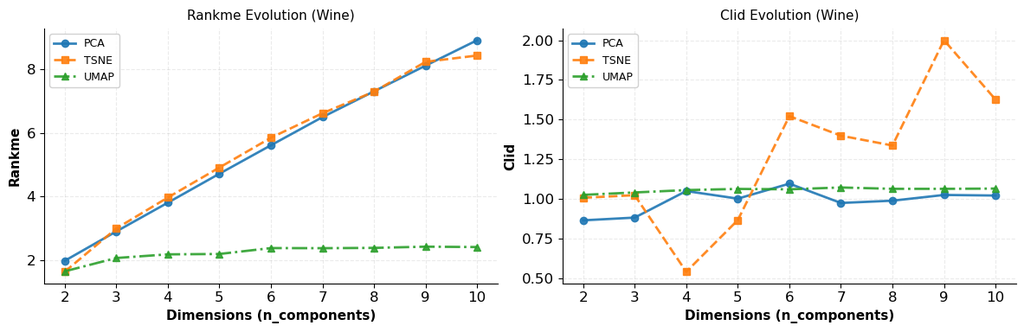

```
 Correlation Evolution Plot
📁 Saved: Wine/Wine_correlation_evolution.png
```

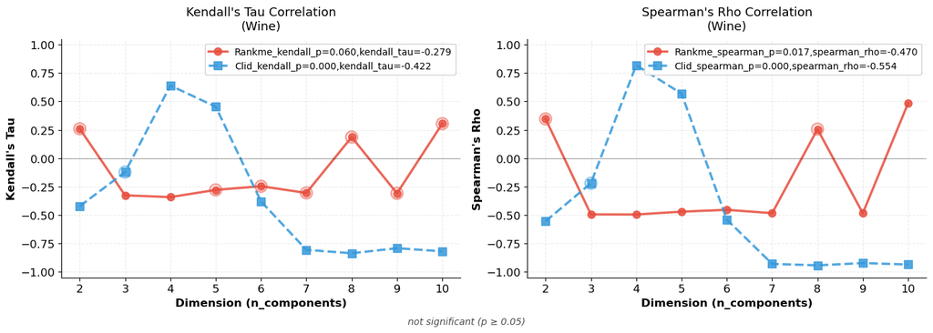

```
Metric vs Accuracy Scatter Plot
📁 Saved: Wine/Wine_scatter_metric_vs_accuracy.png
```

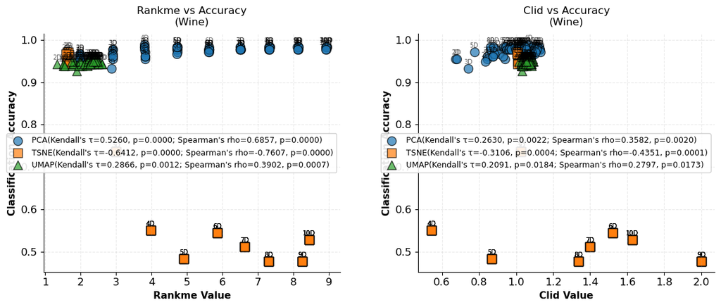

```python
available_datasets = ['Wine']
save_directory = "Wine"
dataset_name = "Wine"

# Run experiments with fixed parameters
evaluation_results, correlation_df = run_with_fixed_parameters(
    reduction_methods=['pca', 'tsne', 'umap'],
    dataset_names=['Wine'],
    n_components_list=[2, 3, 4, 5,6,7,8,9,10]  # Test different dimensions
)


# 1. Metric evolution plot
print(" Metric Evolution Plot")
visualize_metric_evolution(evaluation_results, save_path=save_directory, eval_metrics=['rankme', 'clid'])

# 2. Correlation evolution plot
print(" Correlation Evolution Plot")
plot_correlation_evolution(correlation_df, save_path=save_directory)

# 3. Scatter plot
print("Metric vs Accuracy Scatter Plot")
plot_metric_vs_accuracy_scatter(evaluation_results, save_path=save_directory, show_regression=True)
```

### 4.5 Experiment with dataset of Breast Cancer

```
Processing dataset: Breast Cancer
Original shape: (569, 30)
Number of features: dataset_Breast Cancer: 30
Correlation Analysis (Fixed Dimension, Comparing Different Methods)
Saved plot to Breast_Cancer/Breast_Cancer_metric_evolution_across_methods.png
```

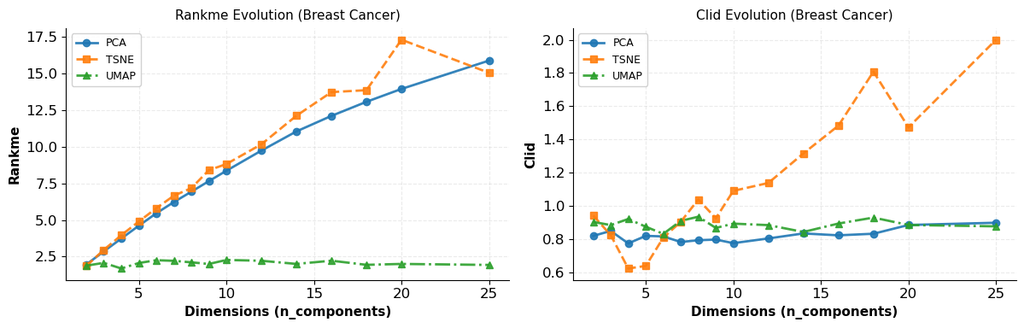

```
📁 Saved: Breast_Cancer/Breast_Cancer_correlation_evolution.png
```

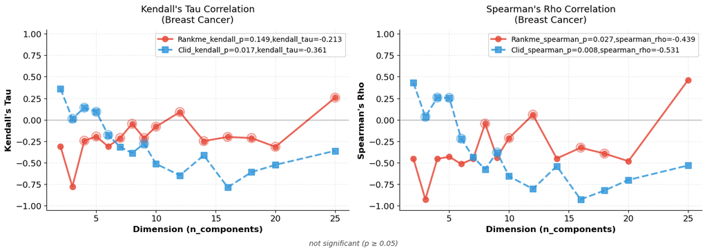

```
📁 Saved: Breast_Cancer/Breast_Cancer_scatter_metric_vs_accuracy.png
```

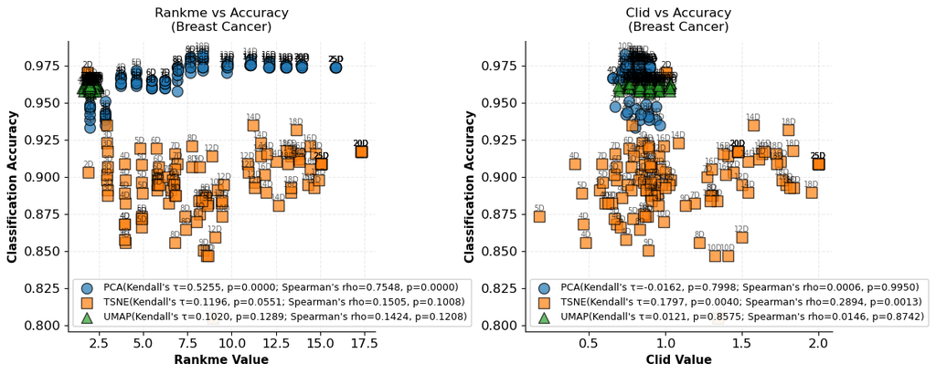

```python
available_datasets = ['Breast Cancer']
save_directory = "Breast_Cancer"
dataset_name = "Breast Cancer"

# Run experiments with fixed parameters
evaluation_results, correlation_df = run_with_fixed_parameters(
    reduction_methods=['pca', 'tsne', 'umap'],
    dataset_names=['Breast Cancer'],
    n_components_list=[2, 3, 4, 5, 6, 7, 8 ,9, 10, 12, 14, 16, 18, 20, 25]  # Test different dimensions
)



# 1. Metric evolution + Correlation + Scatter plots
visualize_metric_evolution(evaluation_results, save_path=save_directory, eval_metrics=['rankme', 'clid'])
plot_correlation_evolution(correlation_df, save_path=save_directory)
plot_metric_vs_accuracy_scatter(evaluation_results, save_path=save_directory, show_regression=True)
```

### 4.6 Experiment with dataset of Digits

```
Processing dataset: Digits
Original shape: (1797, 64)
Number of features: dataset_Digits: 64
Correlation Analysis (Fixed Dimension, Comparing Different Methods)
Saved plot to Digits/Digits_metric_evolution_across_methods.png
```

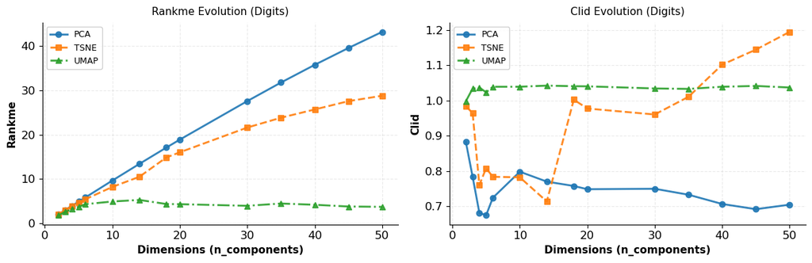

```
📁 Saved: Digits_Correlation_Plots/Digits_correlation_evolution.png
```

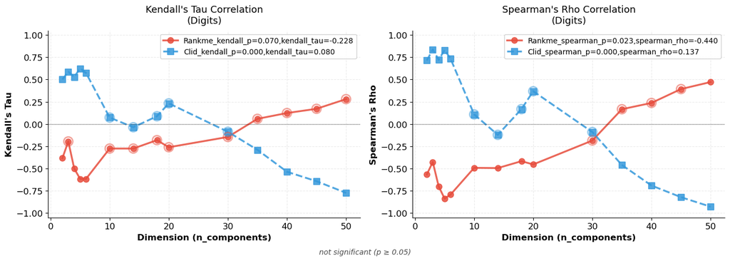

```
📁 Saved: Digits/Digits_scatter_metric_vs_accuracy.png
```

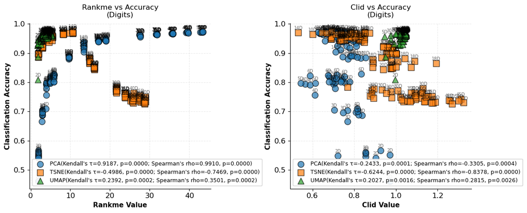

```python
available_datasets = ['Digits']
save_directory = "Digits"
dataset_name = "Digits"

# Run experiments with fixed parameters
evaluation_results, correlation_df= run_with_fixed_parameters(
    reduction_methods=['pca', 'tsne', 'umap'],
    dataset_names=['Digits'],
    n_components_list=[2,  3, 4, 5,  6,  10,  14,  18, 20, 30, 35, 40 ,45, 50]  # Test different dimensions
)



# 1. Evolution plot (like teacher's whiteboard - showing trend with dimensions)
visualize_metric_evolution(evaluation_results, eval_metrics=['rankme', 'clid'],save_path=save_directory)
plot_correlation_evolution(correlation_df, save_path="Digits_Correlation_Plots")
plot_metric_vs_accuracy_scatter(evaluation_results, save_path=save_directory, show_regression=True)
```

### 4.7 Experiment with dataset of Olivetti Faces

```
Processing dataset: Olivetti Faces
Original shape: (400, 4096)
Number of features: dataset_Olivetti Faces: 4096
Correlation Analysis (Fixed Dimension, Comparing Different Methods)
Saved plot to Olivetti Faces/Olivetti_Faces_metric_evolution_across_methods.png
```

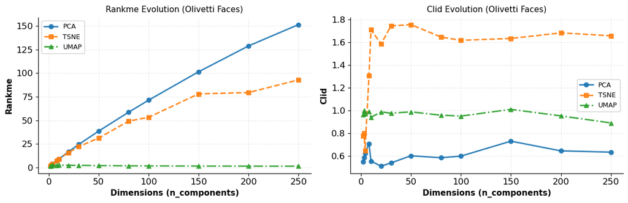

```
📁 Saved: Olivetti Faces/Olivetti_Faces_correlation_evolution.png
```

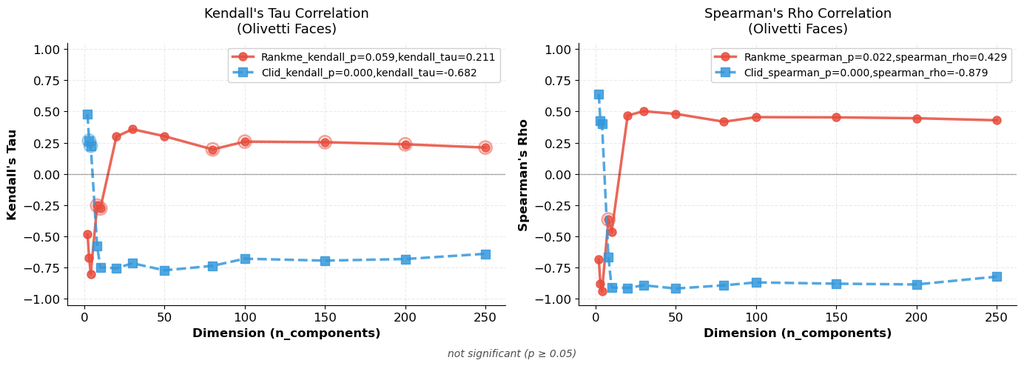

```
📁 Saved: Olivetti Faces/Olivetti_Faces_scatter_metric_vs_accuracy.png
```

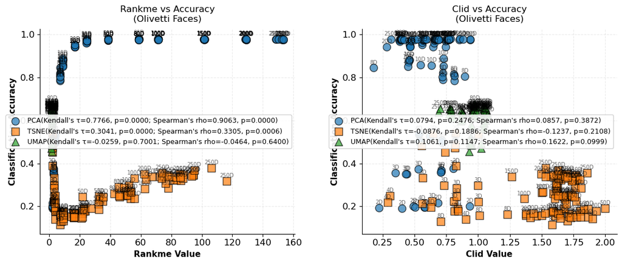

```python
available_datasets = ['Olivetti Faces']
save_directory = 'Olivetti Faces'
dataset_name = 'Olivetti Faces'

# Run experiments with fixed parameters
evaluation_results, correlation_df= run_with_fixed_parameters(
    reduction_methods=['pca', 'tsne', 'umap'],
    dataset_names=['Olivetti Faces'],
    n_components_list=[2,  3,  4, 8, 10, 20, 30, 50, 80, 100, 150, 200, 250]  # Test different dimensions
)

# 1. Evolution plot (like teacher's whiteboard - showing trend with dimensions)
visualize_metric_evolution(evaluation_results, save_path=save_directory)
plot_correlation_evolution(correlation_df, save_path=save_directory)
plot_metric_vs_accuracy_scatter(evaluation_results, save_path=save_directory, show_regression=True)
```